# Introvert vs Extrovert Analysis Project

## Introduction

This project analyzes personality data to explore differences between introverts and extroverts. The dataset contains information about personality types, friend circle sizes, and time spent alone.

Research questions:

- How does friend circle size differ between introverts and extroverts?
- Is there a correlation between personality type and time spent alone?
- What's the distribution of different personality types in the dataset?

## Data Overview and Exploration

```python
import pandas as pd
import matplotlib.pyplot as plt

df = pd.read_csv('personality_dataset.csv')

print(f"\nFirst ten rows: ")
df.head(10)
```

```
First ten rows:
```

|  | Time_spent_Alone | Stage_fear | Social_event_attendance | Going_outside | Drained_after_socializing | Friends_circle_size | Post_frequency | Personality |
| --- | --- | --- | --- | --- | --- | --- | --- | --- |
| 0 | 4.0 | No | 4.0 | 6.0 | No | 13.0 | 5.0 | Extrovert |
| 1 | 9.0 | Yes | 0.0 | 0.0 | Yes | 0.0 | 3.0 | Introvert |
| 2 | 9.0 | Yes | 1.0 | 2.0 | Yes | 5.0 | 2.0 | Introvert |
| 3 | 0.0 | No | 6.0 | 7.0 | No | 14.0 | 8.0 | Extrovert |
| 4 | 3.0 | No | 9.0 | 4.0 | No | 8.0 | 5.0 | Extrovert |
| 5 | 1.0 | No | 7.0 | 5.0 | No | 6.0 | 6.0 | Extrovert |
| 6 | 4.0 | No | 9.0 | NaN | No | 7.0 | 7.0 | Extrovert |
| 7 | 2.0 | No | 8.0 | 4.0 | No | 7.0 | 8.0 | Extrovert |
| 8 | 10.0 | Yes | 1.0 | 3.0 | Yes | 0.0 | 3.0 | Introvert |
| 9 | 0.0 | No | 8.0 | 6.0 | No | 13.0 | 8.0 | Extrovert |

```python
print(f"\n\nDatatypes and statistics: ")
print("\n\nDataset information:" )
df.info()
```

```
Datatypes and statistics:


Dataset information:
<class 'pandas.core.frame.DataFrame'>
RangeIndex: 2900 entries, 0 to 2899
Data columns (total 8 columns):
 #   Column                     Non-Null Count  Dtype
---  ------                     --------------  -----
 0   Time_spent_Alone           2837 non-null   float64
 1   Stage_fear                 2827 non-null   object
 2   Social_event_attendance    2838 non-null   float64
 3   Going_outside              2834 non-null   float64
 4   Drained_after_socializing  2848 non-null   object
 5   Friends_circle_size        2823 non-null   float64
 6   Post_frequency             2835 non-null   float64
 7   Personality                2900 non-null   object
dtypes: float64(5), object(3)
memory usage: 181.4+ KB
```

## Analysis of Friend Circle Sizes

In this section, we examine how many friends people with different personality types tend to have.

Here we visualize the relationship between personality types and time spent in solitude.

```python
stats = df[df['Friends_circle_size'] > 10]
print(f"Personality of people with big friend groups")
stats[['Friends_circle_size', 'Personality', 'Time_spent_Alone']]
```

```
Personality of people with big friend groups
```

|  | Friends_circle_size | Personality | Time_spent_Alone |
| --- | --- | --- | --- |
| 0 | 13.0 | Extrovert | 4.0 |
| 3 | 14.0 | Extrovert | 0.0 |
| 9 | 13.0 | Extrovert | 0.0 |
| 10 | 15.0 | Extrovert | 3.0 |
| 12 | 14.0 | Extrovert | 3.0 |
| ... | ... | ... | ... |
| 2872 | 13.0 | Extrovert | 0.0 |
| 2875 | 14.0 | Extrovert | 0.0 |
| 2878 | 12.0 | Extrovert | 2.0 |
| 2894 | 12.0 | Extrovert | 0.0 |
| 2896 | 14.0 | Extrovert | 3.0 |

608 rows × 3 columns

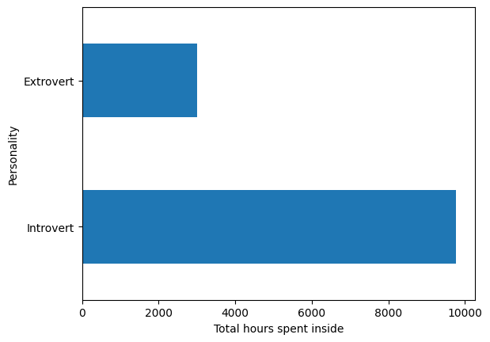

```python
friends = df.groupby('Personality')['Time_spent_Alone'].sum()
friends = friends.sort_values(ascending=False)
friends.plot(kind='barh')
plt.xlabel("Total hours spent inside")
plt.savefig('diagram1.png')
plt.show()
friends.to_csv('resultat.csv')
```

### Distribution Analysis

The pie chart shows that 48.6% of our sample consists of introverts while 51.4% are extroverts. This distribution might affect other findings in our analysis.

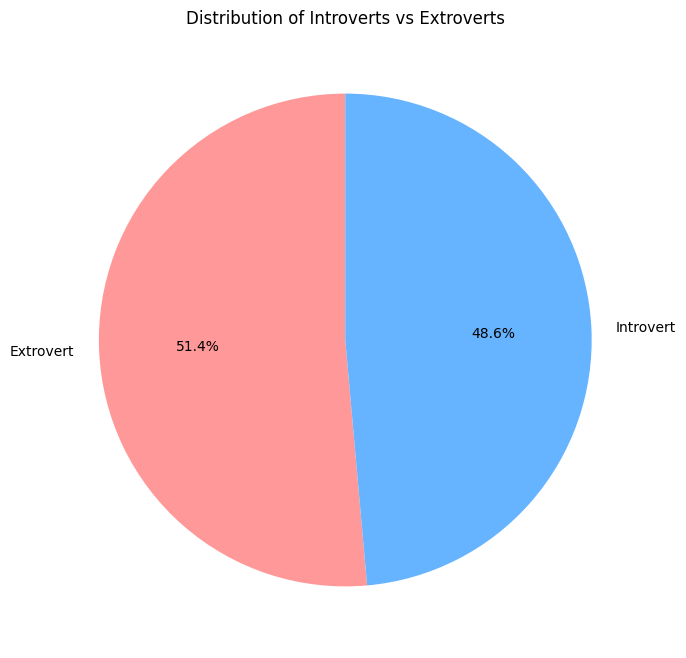

```python
introvert_extrovert_counts = df['Personality'].value_counts()

plt.figure(figsize=(8, 8))
introvert_extrovert_counts.plot(kind='pie',
                               autopct='%1.1f%%',
                               colors=['#ff9999','#66b3ff'],
                               startangle=90)
plt.title('Distribution of Introverts vs Extroverts')
plt.ylabel('')
plt.savefig('diagram2.png')
plt.show()
```

## Conclusions and Insights

### Limitations

- Sample size considerations
- Potential biases in data collection
- Other limitations

### Future Analysis Ideas

- Explore correlation with other variables like age or occupation
- Compare with other personality frameworks
- Conduct time-series analysis to see if these patterns change over time